# MPS_YHC

Hongsun Kim

2020 8 19

# Inclusion criteria

## 선정기준

- 1995년 11월부터 2018년 12월까지 급성 A형 대동맥 박리술 환자 중 수술을 받은 자

## 제외기준

- 급성 대동맥 박리가 아닌 경우, 대동맥 박리 없는 대동맥 벽내 혈종 환자

N=470

CMPS - 관류부전 + 임상적 증거

SCMPS - 관류부전 w/o 임상적 증거

# 기본분석

|  | 1 | 2 | 3 | Total | p |  |
| --- | --- | --- | --- | --- | --- | --- |
|  | (N=79) | (N=99) | (N=292) | (N=470) |  |  |
| Info_Male | 44 (55.7%) | 59 (59.6%) | 123 (42.1%) | 226 (48.1%) |  | 0.004 |
| Info_Age | 57.4 ± 15.4 | 56.8 ± 14.5 | 57.7 ± 14.7 | 57.4 ± 14.7 | 0.759 |  |

|  | 1 | 2 | 3 | Total | p |  |
| --- | --- | --- | --- | --- | --- | --- |
|  | (N=79) | (N=99) | (N=292) | (N=470) |  |  |
| Cate_CMPS | 79 (100.0%) | 0 ( 0.0%) | 0 ( 0.0%) | 79 (16.8%) |  | < 0.001 |
| Cate_NeuMPS | 26 (32.9%) | 0 ( 0.0%) | 0 ( 0.0%) | 26 ( 5.5%) | < 0.001 |  |
| Cate_CoroMPS | 12 (15.2%) | 0 ( 0.0%) | 0 ( 0.0%) | 12 ( 2.6%) | < 0.001 |  |
| Cate_RenMPS | 19 (24.1%) | 0 ( 0.0%) | 0 ( 0.0%) | 19 ( 4.0%) | < 0.001 |  |
| Cate_ExtMPS | 32 (40.5%) | 0 ( 0.0%) | 0 ( 0.0%) | 32 ( 6.8%) | < 0.001 |  |
| Cate_VisMPS | 12 (15.2%) | 0 ( 0.0%) | 0 ( 0.0%) | 12 ( 2.6%) | < 0.001 |  |
| Cate_SCMPS | 49 (62.0%) | 99 (100.0%) | 0 ( 0.0%) | 148 (31.5%) | < 0.001 |  |
| Cate_NeuSCM | 12 (15.2%) | 24 (24.2%) | 0 ( 0.0%) | 36 ( 7.7%) | < 0.001 |  |
| Cate_coroSCM | 21 (26.6%) | 43 (43.4%) | 0 ( 0.0%) | 64 (13.6%) | < 0.001 |  |
| Cate_renSCM | 14 (17.7%) | 20 (20.2%) | 0 ( 0.0%) | 34 ( 7.2%) | < 0.001 |  |
| Cate_ExtSCM | 19 (24.1%) | 22 (22.2%) | 0 ( 0.0%) | 41 ( 8.7%) | < 0.001 |  |
| Cate_VisSCM | 6 ( 7.6%) | 10 (10.1%) | 0 ( 0.0%) | 16 ( 3.4%) | < 0.001 |  |

|  | 1 | 2 | 3 | Total | p |  |
| --- | --- | --- | --- | --- | --- | --- |
|  | (N=79) | (N=99) | (N=292) | (N=470) |  |  |
| PMH_preHTN | 54 (68.4%) | 53 (53.5%) | 169 (57.9%) | 276 (58.7%) |  | 0.122 |
| PMH_preDM | 4 ( 5.1%) | 5 ( 5.1%) | 14 ( 4.8%) | 23 ( 4.9%) | 1.000 |  |
| PMH_preSmok |  |  |  |  | 0.123 |  |
| 0 | 58 (73.4%) | 67 (67.7%) | 218 (74.7%) | 343 (73.0%) |  |  |
| 1 | 14 (17.7%) | 28 (28.3%) | 65 (22.3%) | 107 (22.8%) |  |  |
| 2 | 7 ( 8.9%) | 4 ( 4.0%) | 9 ( 3.1%) | 20 ( 4.3%) |  |  |
| PMH_preCVAhx | 12 (15.2%) | 7 ( 7.1%) | 15 ( 5.1%) | 34 ( 7.2%) | 0.009 |  |
| PMH_preCLD | 1 ( 1.3%) | 2 ( 2.0%) | 4 ( 1.4%) | 7 ( 1.5%) | 0.861 |  |
| PMH_preCAD | 6 ( 7.6%) | 3 ( 3.0%) | 7 ( 2.4%) | 16 ( 3.4%) | 0.102 |  |
| PMH_prePVD | 16 (20.3%) | 2 ( 2.0%) | 1 ( 0.3%) | 19 ( 4.0%) | < 0.001 |  |
| PMH_preCKD | 1 ( 1.3%) | 0 ( 0.0%) | 4 ( 1.4%) | 5 ( 1.1%) | 0.671 |  |
| PMH_preAKI | 5 ( 6.3%) | 1 ( 1.0%) | 0 ( 0.0%) | 6 ( 1.3%) | < 0.001 |  |
| PMH_Redo | 0 ( 0.0%) | 4 ( 4.0%) | 6 ( 2.1%) | 10 ( 2.1%) | 0.191 |  |
| PMH_RedoAo | 1 ( 1.3%) | 2 ( 2.0%) | 1 ( 0.3%) | 4 ( 0.9%) | 0.155 |  |
| PMH_Marfan | 7 ( 8.9%) | 9 ( 9.1%) | 33 (11.3%) | 49 (10.4%) | 0.728 |  |
| PMH_LDS | 1 ( 1.3%) | 0 ( 0.0%) | 1 ( 0.3%) | 2 ( 0.4%) | 0.352 |  |

|  | 1 | 2 | 3 | Total | p |  |
| --- | --- | --- | --- | --- | --- | --- |
|  | (N=79) | (N=99) | (N=292) | (N=470) |  |  |
| Lab_Hb | 12.7 ± 2.1 | 12.7 ± 2.1 | 12.3 ± 1.9 | 12.4 ± 2.0 |  | 0.060 |
| Lab_HCT | 38.2 ± 6.0 | 37.8 ± 6.0 | 36.9 ± 5.5 | 37.3 ± 5.7 | 0.044 |  |
| Lab_PLT | 171.6 ± 61.6 | 185.3 ± 83.9 | 190.3 ± 111.9 | 186.2 ± 99.7 | 0.156 |  |
| Lab_CRP | 2.6 ± 4.8 | 2.9 ± 4.7 | 2.9 ± 5.2 | 2.8 ± 5.0 | 0.693 |  |
| Lab_AST | 100.7 ± 231.3 | 107.2 ± 256.5 | 44.5 ± 74.2 | 67.1 ± 163.9 | 0.001 |  |
| Lab_ALT | 78.2 ± 203.1 | 79.3 ± 210.5 | 32.0 ± 41.2 | 49.7 ± 132.8 | 0.001 |  |
| Lab_Tb | 0.9 ± 0.6 | 1.0 ± 1.1 | 0.9 ± 0.4 | 0.9 ± 0.7 | 0.803 |  |
| Lab_BUN | 22.8 ± 10.9 | 20.4 ± 12.1 | 17.3 ± 7.7 | 18.9 ± 9.6 | < 0.001 |  |
| Lab_Cr | 1.4 ± 1.0 | 1.3 ± 1.4 | 1.1 ± 0.9 | 1.2 ± 1.0 | 0.003 |  |
| Lab_eGFR | 67.6 ± 33.7 | 75.0 ± 33.6 | 81.2 ± 30.7 | 77.3 ± 32.2 | 0.008 |  |
| Lab_Amylise | 69.4 ± 47.0 | 68.1 ± 54.5 | 59.7 ± 26.9 | 63.2 ± 38.2 | 0.130 |  |
| Lab_Lipase | 44.0 ± 34.1 | 46.4 ± 52.5 | 35.9 ± 24.1 | 39.6 ± 33.8 | 0.111 |  |
| Lab_CKMB | 24.1 ± 69.2 | 17.0 ± 43.8 | 2.4 ± 4.8 | 9.8 ± 37.4 | < 0.001 |  |
| Lab_TnI | 4.6 ± 17.9 | 4.8 ± 17.9 | 0.1 ± 0.1 | 2.0 ± 11.7 | 0.005 |  |

|  | 1 | 2 | 3 | Total | p |  |
| --- | --- | --- | --- | --- | --- | --- |
|  | (N=79) | (N=99) | (N=292) | (N=470) |  |  |
| Op_SurType |  |  |  |  |  |  |
| 1 | 12 (15.2%) | 26 (26.3%) | 66 (22.6%) | 104 (22.1%) |  |  |
| 2 | 47 (59.5%) | 52 (52.5%) | 146 (50.0%) | 245 (52.1%) |  |  |
| 3 | 4 ( 5.1%) | 4 ( 4.0%) | 13 ( 4.5%) | 21 ( 4.5%) |  |  |
| 4 | 16 (20.3%) | 17 (17.2%) | 67 (22.9%) | 100 (21.3%) |  |  |
| Op_Root | 13 (16.5%) | 18 (18.2%) | 68 (23.3%) | 99 (21.1%) | 0.305 |  |
| Op_Bentall | 10 (12.7%) | 9 ( 9.1%) | 39 (13.4%) | 58 (12.3%) | 0.535 |  |
| Op_sparing | 3 ( 3.8%) | 9 ( 9.1%) | 29 ( 9.9%) | 41 ( 8.7%) | 0.228 |  |
| Op_Elephant | 2 ( 2.5%) | 5 ( 5.1%) | 9 ( 3.1%) | 16 ( 3.4%) | 0.624 |  |
| Op_Frozen | 2 ( 2.5%) | 0 ( 0.0%) | 2 ( 0.7%) | 4 ( 0.9%) | 0.220 |  |

|  | 1 | 2 | 3 | Total | p |  |
| --- | --- | --- | --- | --- | --- | --- |
|  | (N=79) | (N=99) | (N=292) | (N=470) |  |  |
| Comb_Surgery | 51 (64.6%) | 48 (48.5%) | 114 (39.0%) | 213 (45.3%) |  | < 0.001 |
| Comb_Avsurgery | 31 (39.2%) | 36 (36.4%) | 84 (28.8%) | 151 (32.1%) | 0.125 |  |
| Comb_CABG | 13 (16.5%) | 11 (11.1%) | 22 ( 7.5%) | 46 ( 9.8%) | 0.054 |  |
| Comb_Mvsurgery | 0 ( 0.0%) | 1 ( 1.0%) | 4 ( 1.4%) | 5 ( 1.1%) | 0.828 |  |
| Comb_Tvsurgery | 2 ( 2.5%) | 0 ( 0.0%) | 2 ( 0.7%) | 4 ( 0.9%) | 0.220 |  |
| Comb_Maze | 0 ( 0.0%) | 0 ( 0.0%) | 2 ( 0.7%) | 2 ( 0.4%) | 1.000 |  |
| Comb_PFO | 2 ( 2.5%) | 3 ( 3.0%) | 5 ( 1.7%) | 10 ( 2.1%) | 0.585 |  |
| Comb_PVDbypass | 13 (16.5%) | 4 ( 4.0%) | 3 ( 1.0%) | 20 ( 4.3%) | < 0.001 |  |

|  | 1 | 2 | 3 | Total | p |  |
| --- | --- | --- | --- | --- | --- | --- |
|  | (N=79) | (N=99) | (N=292) | (N=470) |  |  |
| CPB_CPB | 225.0 ± 79.3 | 205.8 ± 57.4 | 209.8 ± 73.7 | 211.5 ± 71.8 |  | 0.187 |
| CPB_ACC | 138.3 ± 57.7 | 132.4 ± 45.5 | 136.8 ± 58.6 | 136.2 ± 55.9 | 0.984 |  |
| CPB_TCA | 37.4 ± 14.8 | 41.2 ± 19.3 | 43.6 ± 28.4 | 42.0 ± 24.7 | 0.098 |  |
| CPB_SCP | 52.5 ± 32.0 | 55.2 ± 33.8 | 56.6 ± 34.8 | 55.5 ± 34.0 | 0.412 |  |
| CPB_nasal_T | 15.9 ± 2.4 | 16.0 ± 3.1 | 16.2 ± 2.9 | 16.1 ± 2.9 | 0.392 |  |
| CPB_rect_bladder_T | 21.0 ± 2.7 | 20.6 ± 3.0 | 20.9 ± 2.9 | 20.8 ± 2.9 | 0.992 |  |

|  | 1 | 2 | 3 | Total | p |  |
| --- | --- | --- | --- | --- | --- | --- |
|  | (N=79) | (N=99) | (N=292) | (N=470) |  |  |
| PostOp_ICU_h | 220.3 ± 567.9 | 139.6 ± 140.1 | 136.6 ± 398.9 | 151.3 ± 397.2 |  | 0.138 |
| PostOp_Vent_h | 72.9 ± 112.1 | 44.5 ± 62.8 | 36.5 ± 75.2 | 44.3 ± 81.3 | 0.001 |  |
| PostOp_HD | 25.1 ± 29.7 | 20.5 ± 24.1 | 16.8 ± 18.8 | 19.0 ± 22.3 | 0.002 |  |

|  | 1 | 2 | 3 | Total | p |  |
| --- | --- | --- | --- | --- | --- | --- |
|  | (N=79) | (N=99) | (N=292) | (N=470) |  |  |
| Cx_Tracheo | 7 ( 8.9%) | 1 ( 1.0%) | 6 ( 2.1%) | 14 ( 3.0%) |  | 0.007 |
| Cx_Pneumonia | 9 (11.4%) | 7 ( 7.1%) | 18 ( 6.2%) | 34 ( 7.2%) | 0.281 |  |
| Cx_Vent_7d | 14 (17.7%) | 6 ( 6.1%) | 12 ( 4.1%) | 32 ( 6.8%) | < 0.001 |  |
| Cx_Reintu | 8 (10.1%) | 11 (11.1%) | 15 ( 5.1%) | 34 ( 7.2%) | 0.077 |  |
| Cx_Bleeding | 9 (11.4%) | 11 (11.1%) | 23 ( 7.9%) | 43 ( 9.1%) | 0.471 |  |
| Cx_RBC | 3.0 [ 1.0; 7.0] | 2.0 [ 0.0; 5.0] | 2.0 [ 0.0; 4.0] | 2.0 [ 0.0; 5.0] | 0.001 |  |
| Cx_FFP | 2.0 [ 0.0; 5.0] | 2.0 [ 0.0; 5.0] | 2.0 [ 0.0; 3.0] | 2.0 [ 0.0; 4.0] | 0.022 |  |
| Cx_ARF | 19 (24.1%) | 12 (12.1%) | 21 ( 7.2%) | 52 (11.1%) | < 0.001 |  |
| Cx_Supf_WI | 1 ( 1.3%) | 0 ( 0.0%) | 1 ( 0.3%) | 2 ( 0.4%) | 0.352 |  |
| Cx_DSWI | 2 ( 2.5%) | 0 ( 0.0%) | 3 ( 1.0%) | 5 ( 1.1%) | 0.192 |  |
| Cx_Graft_inf | 0 ( 0.0%) | 0 ( 0.0%) | 3 ( 1.0%) | 3 ( 0.6%) | 0.755 |  |
| Cx_Arrythmia | 26 (32.9%) | 23 (23.2%) | 77 (26.4%) | 126 (26.8%) | 0.337 |  |
| Cx_PMI | 1 ( 1.3%) | 0 ( 0.0%) | 1 ( 0.3%) | 2 ( 0.4%) | 0.352 |  |
| Cx_CHF | 2 ( 2.5%) | 3 ( 3.0%) | 2 ( 0.7%) | 7 ( 1.5%) | 0.098 |  |
| Cx_CVA_TIA | 2 ( 2.5%) | 5 ( 5.1%) | 6 ( 2.1%) | 13 ( 2.8%) | 0.283 |  |
| Cx_CVA_Stroke | 10 (12.7%) | 5 ( 5.1%) | 12 ( 4.1%) | 27 ( 5.7%) | 0.026 |  |
| Cx_Brain_Hemo | 3 ( 3.8%) | 2 ( 2.0%) | 3 ( 1.0%) | 8 ( 1.7%) | 0.179 |  |
| Cx_Seizure | 6 ( 7.6%) | 2 ( 2.0%) | 6 ( 2.1%) | 14 ( 3.0%) | 0.046 |  |
| Cx_CVA_Sequela | 11 (13.9%) | 3 ( 3.0%) | 8 ( 2.7%) | 22 ( 4.7%) | 0.001 |  |

|  | 1 | 2 | 3 | Total | p |  |
| --- | --- | --- | --- | --- | --- | --- |
|  | (N=79) | (N=99) | (N=292) | (N=470) |  |  |
| DO_interval | 16.7 ± 78.3 | 11.4 ± 29.9 | 12.9 ± 34.6 | 13.2 ± 44.4 |  | 0.651 |

# 생존분석

## Overall(long term) Survival

Call: survfit(formula = TS ~ 1, data = anal_data)

```
  n  events  median 0.95LCL 0.95UCL
470     151     180     161     202
```

Call: survfit(formula = TS ~ 1, data = anal_data)

time n.risk n.event survival std.err lower 95% CI upper 95% CI 60 241 74 0.821 0.0193 0.784 0.86 Call: survfit(formula = TS ~ 1, data = anal_data)

time n.risk n.event survival std.err lower 95% CI upper 95% CI 120 125 110 0.67 0.0279 0.617 0.727

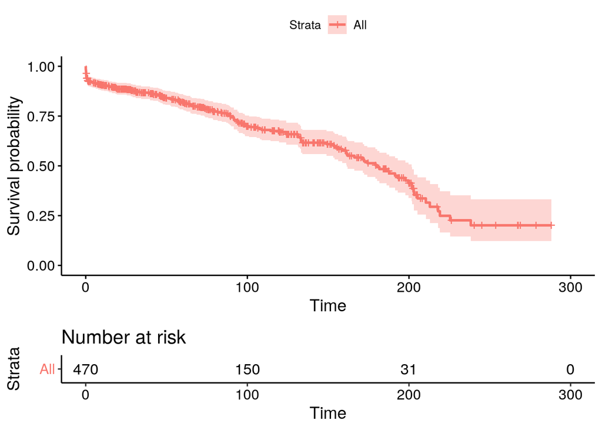

Call: survfit(formula = TS ~ Cate_Gr, data = anal_data)

```
        n events median 0.95LCL 0.95UCL
```

Cate_Gr=1 79 29 174 124 NA Cate_Gr=2 99 37 179 106 219 Cate_Gr=3 292 85 193 161 210 Call: survfit(formula = TS ~ Cate_Gr, data = anal_data)

```
            Cate_Gr=1
    time       n.risk      n.event     survival      std.err lower 95% CI upper 95% CI
 60.0000      31.0000      22.0000       0.6989       0.0549       0.5991       0.8153

            Cate_Gr=2
    time       n.risk      n.event     survival      std.err lower 95% CI upper 95% CI
 60.0000      43.0000      17.0000       0.7835       0.0484       0.6942       0.8844

            Cate_Gr=3
    time       n.risk      n.event     survival      std.err lower 95% CI upper 95% CI
 60.0000     167.0000      35.0000       0.8651       0.0215       0.8240       0.9084
```

Call: survfit(formula = TS ~ Cate_Gr, data = anal_data)

```
            Cate_Gr=1
    time       n.risk      n.event     survival      std.err lower 95% CI upper 95% CI
120.0000      17.0000      24.0000       0.6513       0.0607       0.5426       0.7818

            Cate_Gr=2
    time       n.risk      n.event     survival      std.err lower 95% CI upper 95% CI
120.0000      24.0000      26.0000       0.5892       0.0675       0.4706       0.7376

            Cate_Gr=3
    time       n.risk      n.event     survival      std.err lower 95% CI upper 95% CI
120.0000      84.0000      60.0000       0.7043       0.0342       0.6404       0.7745
```

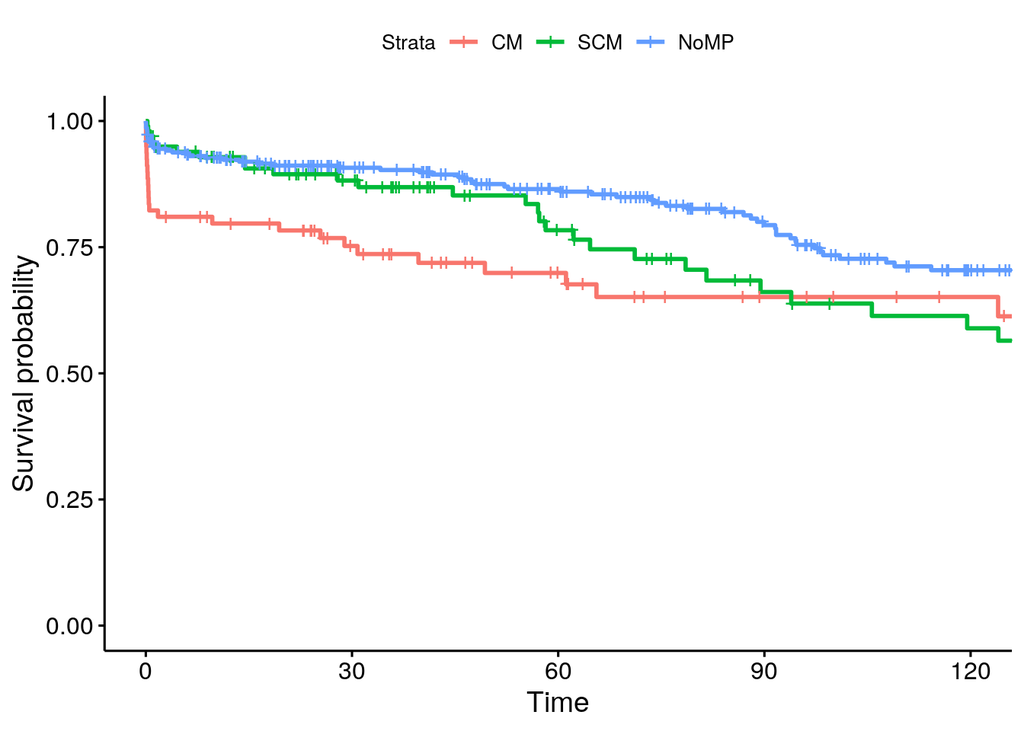

Call: survdiff(formula = TS ~ Cate_Gr, data = .)

```
        N Observed Expected (O-E)^2/E (O-E)^2/V
```

Cate_Gr=1 79 29 18.5 6.00 7.28 Cate_Gr=3 292 85 95.5 1.16 7.28

Chisq= 7.3 on 1 degrees of freedom, p= 0.007 Call: survdiff(formula = TS ~ Cate_Gr, data = .)

```
        N Observed Expected (O-E)^2/E (O-E)^2/V
```

Cate_Gr=2 99 37 29.5 1.910 2.54 Cate_Gr=3 292 85 92.5 0.609 2.54

Chisq= 2.5 on 1 degrees of freedom, p= 0.1 Call: survdiff(formula = TS ~ Cate_Gr, data = .)

```
       N Observed Expected (O-E)^2/E (O-E)^2/V
```

Cate_Gr=1 79 29 24.1 0.99 1.65 Cate_Gr=2 99 37 41.9 0.57 1.65

Chisq= 1.6 on 1 degrees of freedom, p= 0.2

mycph : perform coxph of individual expecting variables

Call: TS ~ ., data= cox_trim

PMH_LDS was excluded : infinite Comb_Tvsurgery was excluded : infinite Comb_Maze was excluded : infinite

|  | HR | lcl | ucl | p |
| --- | --- | --- | --- | --- |
| Info_Male | 0.76 | 0.55 | 1.06 | 0.10 |
| Info_Age | 1.04 | 1.03 | 1.06 | 0.00 |
| Cate_CMPS | 1.68 | 1.12 | 2.53 | 0.01 |
| Cate_NeuMPS | 2.80 | 1.46 | 5.38 | 0.00 |
| Cate_CoroMPS | 0.94 | 0.35 | 2.55 | 0.90 |
| Cate_RenMPS | 2.79 | 1.46 | 5.32 | 0.00 |
| Cate_ExtMPS | 1.65 | 0.95 | 2.87 | 0.07 |
| Cate_VisMPS | 1.26 | 0.40 | 3.96 | 0.69 |
| Cate_SCMPS | 1.63 | 1.17 | 2.26 | 0.00 |
| Cate_NeuSCM | 1.42 | 0.72 | 2.80 | 0.32 |
| Cate_coroSCM | 1.54 | 1.02 | 2.33 | 0.04 |
| Cate_renSCM | 2.11 | 1.34 | 3.33 | 0.00 |
| Cate_ExtSCM | 1.78 | 0.98 | 3.24 | 0.06 |
| Cate_VisSCM | 0.84 | 0.34 | 2.04 | 0.69 |
| Cate_F-2 | 1.35 | 0.91 | 1.99 | 0.13 |
| Cate_F-1 | 1.82 | 1.19 | 2.79 | 0.01 |
| PMH_preHTN | 1.58 | 1.13 | 2.22 | 0.01 |
| PMH_preDM | 1.03 | 0.48 | 2.21 | 0.93 |
| PMH_preCVAhx | 1.48 | 0.78 | 2.83 | 0.23 |
| PMH_preCLD | 1.47 | 0.47 | 4.63 | 0.51 |
| PMH_preCAD | 0.81 | 0.26 | 2.54 | 0.71 |
| PMH_prePVD | 1.31 | 0.58 | 2.98 | 0.51 |
| PMH_preCKD | 1.65 | 0.23 | 11.88 | 0.62 |
| PMH_preAKI | 1.86 | 0.59 | 5.85 | 0.29 |
| PMH_Redo | 0.93 | 0.23 | 3.76 | 0.92 |
| PMH_RedoAo | 0.78 | 0.11 | 5.59 | 0.81 |
| PMH_Marfan | 0.28 | 0.12 | 0.64 | 0.00 |
| PMH_smkTRUE | 0.78 | 0.53 | 1.15 | 0.21 |
| Lab_Hb | 0.89 | 0.82 | 0.96 | 0.00 |
| Lab_HCT | 0.96 | 0.94 | 0.99 | 0.01 |
| Lab_PLT | 1.00 | 1.00 | 1.00 | 0.26 |
| Lab_CRP | 1.04 | 1.00 | 1.08 | 0.03 |
| Lab_AST | 1.00 | 1.00 | 1.00 | 0.01 |
| Lab_ALT | 1.00 | 1.00 | 1.00 | 0.34 |
| Lab_Tb | 0.92 | 0.64 | 1.33 | 0.66 |
| Lab_BUN | 1.01 | 1.00 | 1.02 | 0.12 |
| Lab_Cr | 1.09 | 0.95 | 1.26 | 0.20 |
| Lab_eGFR | 0.99 | 0.98 | 1.00 | 0.01 |
| Lab_Amylise | 1.00 | 1.00 | 1.01 | 0.17 |
| Lab_Lipase | 1.00 | 1.00 | 1.01 | 0.18 |
| Lab_CKMB | 1.01 | 1.00 | 1.01 | 0.00 |
| Lab_TnI | 1.01 | 0.99 | 1.03 | 0.31 |
| Op_Total | 0.69 | 0.43 | 1.11 | 0.12 |
| Op_Root | 0.56 | 0.35 | 0.88 | 0.01 |
| Op_Bentall | 0.90 | 0.57 | 1.44 | 0.67 |
| Op_sparing | 0.17 | 0.04 | 0.68 | 0.01 |
| Op_Elephant | 0.68 | 0.17 | 2.75 | 0.58 |
| Op_Frozen | 1.33 | 0.18 | 9.53 | 0.78 |
| Op_factor2 | 0.96 | 0.66 | 1.39 | 0.82 |
| Op_factor3 | 1.25 | 0.53 | 2.94 | 0.61 |
| Op_factor4 | 0.68 | 0.40 | 1.15 | 0.15 |
| Comb_Surgery | 1.05 | 0.77 | 1.45 | 0.75 |
| Comb_Avsurgery | 1.06 | 0.76 | 1.49 | 0.72 |
| Comb_CABG | 1.49 | 0.96 | 2.30 | 0.08 |
| Comb_Mvsurgery | 0.37 | 0.05 | 2.68 | 0.33 |
| Comb_PFO | 0.89 | 0.28 | 2.79 | 0.84 |
| Comb_PVDbypass | 1.12 | 0.55 | 2.29 | 0.75 |
| CPB_CPB | 1.00 | 1.00 | 1.00 | 0.05 |
| CPB_ACC | 1.00 | 1.00 | 1.00 | 0.25 |
| CPB_TCA | 1.00 | 0.99 | 1.01 | 0.66 |
| CPB_SCP | 0.99 | 0.99 | 1.00 | 0.16 |
| CPB_nasal_T | 0.92 | 0.87 | 0.98 | 0.01 |
| CPB_rect_bladder_T | 0.93 | 0.87 | 0.99 | 0.02 |
| DO_interval | 1.01 | 1.00 | 1.01 | 0.00 |

[1] “p<0.05”

|  | HR | lcl | ucl | p |
| --- | --- | --- | --- | --- |
| Info_Age | 1.04 | 1.03 | 1.06 | 0.00 |
| Cate_CMPS | 1.68 | 1.12 | 2.53 | 0.01 |
| Cate_NeuMPS | 2.80 | 1.46 | 5.38 | 0.00 |
| Cate_RenMPS | 2.79 | 1.46 | 5.32 | 0.00 |
| Cate_SCMPS | 1.63 | 1.17 | 2.26 | 0.00 |
| Cate_coroSCM | 1.54 | 1.02 | 2.33 | 0.04 |
| Cate_renSCM | 2.11 | 1.34 | 3.33 | 0.00 |
| Cate_F-1 | 1.82 | 1.19 | 2.79 | 0.01 |
| PMH_preHTN | 1.58 | 1.13 | 2.22 | 0.01 |
| PMH_Marfan | 0.28 | 0.12 | 0.64 | 0.00 |
| Lab_Hb | 0.89 | 0.82 | 0.96 | 0.00 |
| Lab_HCT | 0.96 | 0.94 | 0.99 | 0.01 |
| Lab_CRP | 1.04 | 1.00 | 1.08 | 0.03 |
| Lab_AST | 1.00 | 1.00 | 1.00 | 0.01 |
| Lab_eGFR | 0.99 | 0.98 | 1.00 | 0.01 |
| Lab_CKMB | 1.01 | 1.00 | 1.01 | 0.00 |
| Op_Root | 0.56 | 0.35 | 0.88 | 0.01 |
| Op_sparing | 0.17 | 0.04 | 0.68 | 0.01 |
| CPB_nasal_T | 0.92 | 0.87 | 0.98 | 0.01 |
| CPB_rect_bladder_T | 0.93 | 0.87 | 0.99 | 0.02 |
| DO_interval | 1.01 | 1.00 | 1.01 | 0.00 |

[1] “p<0.2”

|  | HR | lcl | ucl | p |
| --- | --- | --- | --- | --- |
| Info_Male | 0.76 | 0.55 | 1.06 | 0.10 |
| Info_Age | 1.04 | 1.03 | 1.06 | 0.00 |
| Cate_CMPS | 1.68 | 1.12 | 2.53 | 0.01 |
| Cate_NeuMPS | 2.80 | 1.46 | 5.38 | 0.00 |
| Cate_RenMPS | 2.79 | 1.46 | 5.32 | 0.00 |
| Cate_ExtMPS | 1.65 | 0.95 | 2.87 | 0.07 |
| Cate_SCMPS | 1.63 | 1.17 | 2.26 | 0.00 |
| Cate_coroSCM | 1.54 | 1.02 | 2.33 | 0.04 |
| Cate_renSCM | 2.11 | 1.34 | 3.33 | 0.00 |
| Cate_ExtSCM | 1.78 | 0.98 | 3.24 | 0.06 |
| Cate_F-2 | 1.35 | 0.91 | 1.99 | 0.13 |
| Cate_F-1 | 1.82 | 1.19 | 2.79 | 0.01 |
| PMH_preHTN | 1.58 | 1.13 | 2.22 | 0.01 |
| PMH_Marfan | 0.28 | 0.12 | 0.64 | 0.00 |
| Lab_Hb | 0.89 | 0.82 | 0.96 | 0.00 |
| Lab_HCT | 0.96 | 0.94 | 0.99 | 0.01 |
| Lab_CRP | 1.04 | 1.00 | 1.08 | 0.03 |
| Lab_AST | 1.00 | 1.00 | 1.00 | 0.01 |
| Lab_BUN | 1.01 | 1.00 | 1.02 | 0.12 |
| Lab_eGFR | 0.99 | 0.98 | 1.00 | 0.01 |
| Lab_Amylise | 1.00 | 1.00 | 1.01 | 0.17 |
| Lab_Lipase | 1.00 | 1.00 | 1.01 | 0.18 |
| Lab_CKMB | 1.01 | 1.00 | 1.01 | 0.00 |
| Op_Total | 0.69 | 0.43 | 1.11 | 0.12 |
| Op_Root | 0.56 | 0.35 | 0.88 | 0.01 |
| Op_sparing | 0.17 | 0.04 | 0.68 | 0.01 |
| Op_factor4 | 0.68 | 0.40 | 1.15 | 0.15 |
| Comb_CABG | 1.49 | 0.96 | 2.30 | 0.08 |
| CPB_CPB | 1.00 | 1.00 | 1.00 | 0.05 |
| CPB_SCP | 0.99 | 0.99 | 1.00 | 0.16 |
| CPB_nasal_T | 0.92 | 0.87 | 0.98 | 0.01 |
| CPB_rect_bladder_T | 0.93 | 0.87 | 0.99 | 0.02 |
| DO_interval | 1.01 | 1.00 | 1.01 | 0.00 |

[1] “Info_Male” “Info_Age” “Cate_CMPS” “Cate_NeuMPS” “Cate_RenMPS” “Cate_ExtMPS” “Cate_SCMPS” “Cate_coroSCM” “Cate_renSCM” “Cate_ExtSCM” “Cate_F-2” “Cate_F-1” “PMH_preHTN” “PMH_Marfan” “Lab_Hb” “Lab_HCT” “Lab_CRP” “Lab_AST” “Lab_BUN” “Lab_eGFR” “Lab_Amylise” “Lab_Lipase” “Lab_CKMB” “Op_Total” “Op_Root” “Op_sparing” “Op_factor4” “Comb_CABG” “CPB_CPB” “CPB_SCP” “CPB_nasal_T” “CPB_rect_bladder_T” “DO_interval”

|  | HR | lcl | ucl | se(coef) | z | Pr(>\|z\|) |
| --- | --- | --- | --- | --- | --- | --- |
| Info_Male | 1.163 | 0.697 | 1.939 | 0.261 | 0.577 | 0.5639 |
| Info_Age | 1.054 | 1.033 | 1.075 | 0.010 | 5.065 | < 0.0001 |
| Cate_F-2 | 1.302 | 0.757 | 2.240 | 0.277 | 0.953 | 0.3408 |
| Cate_F-1 | 2.064 | 1.217 | 3.503 | 0.270 | 2.686 | 0.0072 |
| PMH_preHTN | 1.410 | 0.917 | 2.169 | 0.219 | 1.567 | 0.1171 |
| PMH_smkTRUE | 1.512 | 0.889 | 2.571 | 0.271 | 1.525 | 0.1273 |
| PMH_Marfan | 1.035 | 0.325 | 3.289 | 0.590 | 0.058 | 0.9540 |
| Op_Root | 0.687 | 0.327 | 1.441 | 0.378 | -0.993 | 0.3205 |
| Op_Total | 0.583 | 0.335 | 1.015 | 0.283 | -1.908 | 0.0564 |
| Comb_CABG | 1.182 | 0.656 | 2.132 | 0.301 | 0.556 | 0.5780 |
| CPB_CPB | 1.008 | 1.005 | 1.010 | 0.001 | 5.461 | < 0.0001 |
| DO_interval | 1.005 | 1.002 | 1.008 | 0.001 | 3.575 | 0.0004 |
| Call: coxph(formula = TS ~ ., data = .) |  |  |  |  |  |  |

```
Info_Age     Cate_F-1      CPB_CPB  DO_interval
```

4.075091e-07 7.221247e-03 4.729518e-08 3.505507e-04 Start: AIC=1013.15 TS ~ Info_Male + Info_Age + Cate_F + PMH_preHTN + PMH_smk + PMH_Marfan + Op_Root + Op_Total + Comb_CABG + CPB_CPB + DO_interval

```
          Df    AIC
```

- PMH_Marfan 1 1011.1
- Comb_CABG 1 1011.5
- Info_Male 1 1011.5
- Op_Root 1 1012.2 1013.1
- PMH_smk 1 1013.5
- PMH_preHTN 1 1013.7
- Op_Total 1 1015.1
- Cate_F 2 1015.8
- DO_interval 1 1018.4
- CPB_CPB 1 1033.6
- Info_Age 1 1038.5

Step: AIC=1011.15 TS ~ Info_Male + Info_Age + Cate_F + PMH_preHTN + PMH_smk + Op_Root + Op_Total + Comb_CABG + CPB_CPB + DO_interval

```
          Df    AIC
```

- Comb_CABG 1 1009.5
- Info_Male 1 1009.5
- Op_Root 1 1010.3 1011.1
- PMH_smk 1 1011.5
- PMH_preHTN 1 1011.8
- Op_Total 1 1013.1
- Cate_F 2 1013.8
- DO_interval 1 1016.4
- CPB_CPB 1 1031.8
- Info_Age 1 1038.8

Step: AIC=1009.45 TS ~ Info_Male + Info_Age + Cate_F + PMH_preHTN + PMH_smk + Op_Root + Op_Total + CPB_CPB + DO_interval

```
          Df    AIC
```

- Info_Male 1 1007.8
- Op_Root 1 1008.7 1009.5
- PMH_smk 1 1009.7
- PMH_preHTN 1 1010.0
- Op_Total 1 1011.9
- Cate_F 2 1012.7
- DO_interval 1 1014.5
- CPB_CPB 1 1031.7
- Info_Age 1 1036.9

Step: AIC=1007.76 TS ~ Info_Age + Cate_F + PMH_preHTN + PMH_smk + Op_Root + Op_Total + CPB_CPB + DO_interval

```
          Df    AIC
```

- Op_Root 1 1007.2 1007.8
- PMH_preHTN 1 1008.2
- PMH_smk 1 1009.6
- Op_Total 1 1010.2
- Cate_F 2 1011.7
- DO_interval 1 1012.7
- CPB_CPB 1 1030.8
- Info_Age 1 1037.5

Step: AIC=1007.18 TS ~ Info_Age + Cate_F + PMH_preHTN + PMH_smk + Op_Total + CPB_CPB + DO_interval

```
          Df    AIC
```

1007.2 - PMH_preHTN 1 1007.9 - PMH_smk 1 1008.9 - Op_Total 1 1009.2 - Cate_F 2 1011.0 - DO_interval 1 1011.8 - CPB_CPB 1 1029.1 - Info_Age 1 1046.7

|  | HR | lcl | ucl | se(coef) | z | Pr(>\|z\|) |
| --- | --- | --- | --- | --- | --- | --- |
| Info_Age | 1.056 | 1.037 | 1.074 | 0.009 | 6.114 | < 0.0001 |
| Cate_F-2 | 1.385 | 0.828 | 2.319 | 0.263 | 1.240 | 0.2150 |
| Cate_F-1 | 2.140 | 1.276 | 3.589 | 0.264 | 2.884 | 0.0039 |
| PMH_preHTN | 1.414 | 0.928 | 2.156 | 0.215 | 1.613 | 0.1067 |
| PMH_smkTRUE | 1.604 | 1.005 | 2.562 | 0.239 | 1.981 | 0.0476 |
| Op_Total | 0.589 | 0.343 | 1.013 | 0.277 | -1.914 | 0.0557 |
| CPB_CPB | 1.007 | 1.005 | 1.010 | 0.001 | 5.798 | < 0.0001 |
| DO_interval | 1.005 | 1.002 | 1.008 | 0.001 | 3.400 | 0.0007 |
| Call: coxph(formula = TS ~ Info_Age + Cate_F + PMH_preHTN + PMH_smk + Op_Total + CPB_CPB + DO_interval, data = mv_trim) |  |  |  |  |  |  |

## Early Survival

Call: survfit(formula = EM_TS ~ Cate_Gr, data = anal_data)

```
        n events median 0.95LCL 0.95UCL
```

Cate_Gr=1 79 14 NA NA NA Cate_Gr=2 99 3 NA NA NA Cate_Gr=3 292 12 NA NA NA

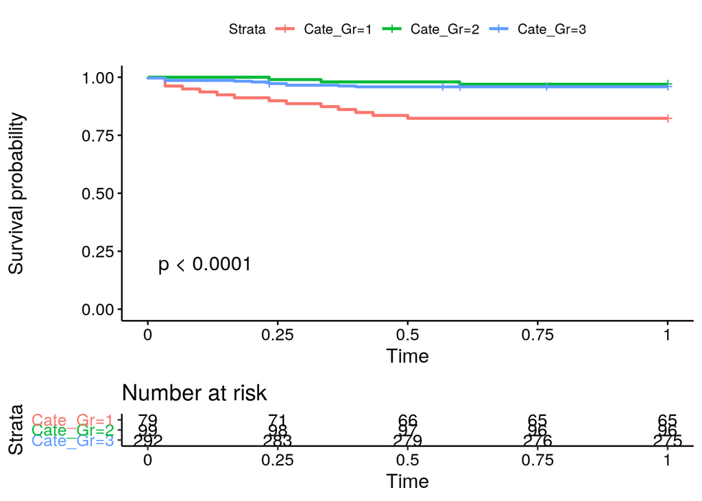

Call: survfit(formula = TS ~ 1, data = anal_data)

time n.risk n.event survival std.err lower 95% CI upper 95% CI 1 436 29 0.938 0.0111 0.917 0.96 Call: survfit(formula = EM_TS ~ Cate_Gr, data = anal_data)

```
            Cate_Gr=1
    time       n.risk      n.event     survival      std.err lower 95% CI upper 95% CI
   1.000       65.000       14.000        0.823        0.043        0.743        0.911

            Cate_Gr=2
    time       n.risk      n.event     survival      std.err lower 95% CI upper 95% CI
  1.0000      96.0000       3.0000       0.9697       0.0172       0.9365       1.0000

            Cate_Gr=3
    time       n.risk      n.event     survival      std.err lower 95% CI upper 95% CI
  1.0000     275.0000      12.0000       0.9589       0.0116       0.9363       0.9819
```

Call: survdiff(formula = EM_TS ~ Cate_Gr, data = .)

```
        N Observed Expected (O-E)^2/E (O-E)^2/V
```

Cate_Gr=1 79 14 5.29 14.32 18.1 Cate_Gr=3 292 12 20.71 3.66 18.1

Chisq= 18.1 on 1 degrees of freedom, p= 2e-05 Call: survdiff(formula = EM_TS ~ Cate_Gr, data = .)

```
        N Observed Expected (O-E)^2/E (O-E)^2/V
```

Cate_Gr=2 99 3 3.84 0.186 0.25 Cate_Gr=3 292 12 11.16 0.064 0.25

Chisq= 0.3 on 1 degrees of freedom, p= 0.6 Call: survdiff(formula = EM_TS ~ Cate_Gr, data = .)

```
       N Observed Expected (O-E)^2/E (O-E)^2/V
```

Cate_Gr=1 79 14 7.19 6.46 11.2 Cate_Gr=2 99 3 9.81 4.73 11.2

Chisq= 11.2 on 1 degrees of freedom, p= 8e-04

mycph : perform coxph of individual expecting variables

Call: EM_TS ~ ., data= cox_trim

Cate_CoroMPS was excluded : infinite PMH_preDM was excluded : infinite PMH_preCAD was excluded : infinite PMH_preCKD was excluded : infinite PMH_RedoAo was excluded : infinite PMH_LDS was excluded : infinite Op_sparing was excluded : infinite Op_Elephant was excluded : infinite Op_Frozen was excluded : infinite Comb_Mvsurgery was excluded : infinite Comb_Tvsurgery was excluded : infinite Comb_Maze was excluded : infinite

|  | HR | lcl | ucl | p |
| --- | --- | --- | --- | --- |
| Info_Male | 1.16 | 0.56 | 2.39 | 0.70 |
| Info_Age | 1.01 | 0.98 | 1.03 | 0.57 |
| Cate_CMPS | 4.95 | 2.39 | 10.26 | 0.00 |
| Cate_NeuMPS | 6.26 | 2.67 | 14.66 | 0.00 |
| Cate_RenMPS | 7.07 | 2.88 | 17.38 | 0.00 |
| Cate_ExtMPS | 4.79 | 2.05 | 11.21 | 0.00 |
| Cate_VisMPS | 5.08 | 1.54 | 16.80 | 0.01 |
| Cate_SCMPS | 2.38 | 1.15 | 4.94 | 0.02 |
| Cate_NeuSCM | 0.90 | 0.21 | 3.80 | 0.89 |
| Cate_coroSCM | 2.97 | 1.35 | 6.52 | 0.01 |
| Cate_renSCM | 6.32 | 2.88 | 13.88 | 0.00 |
| Cate_ExtSCM | 1.70 | 0.59 | 4.88 | 0.33 |
| Cate_VisSCM | 1.04 | 0.14 | 7.63 | 0.97 |
| Cate_F-2 | 0.72 | 0.20 | 2.57 | 0.62 |
| Cate_F-1 | 4.60 | 2.13 | 9.95 | 0.00 |
| PMH_preHTN | 1.34 | 0.62 | 2.88 | 0.46 |
| PMH_preCVAhx | 0.98 | 0.23 | 4.11 | 0.98 |
| PMH_preCLD | 2.61 | 0.35 | 19.17 | 0.35 |
| PMH_prePVD | 5.35 | 2.04 | 14.02 | 0.00 |
| PMH_preAKI | 7.14 | 1.70 | 30.07 | 0.01 |
| PMH_Redo | 1.67 | 0.23 | 12.29 | 0.61 |
| PMH_Marfan | 0.62 | 0.15 | 2.63 | 0.52 |
| PMH_smk1 | 0.87 | 0.35 | 2.15 | 0.77 |
| PMH_smk2 | 0.79 | 0.11 | 5.86 | 0.82 |
| Lab_Hb | 1.05 | 0.87 | 1.25 | 0.64 |
| Lab_HCT | 1.02 | 0.96 | 1.09 | 0.52 |
| Lab_PLT | 1.00 | 1.00 | 1.00 | 0.87 |
| Lab_CRP | 0.99 | 0.90 | 1.10 | 0.90 |
| Lab_AST | 1.00 | 1.00 | 1.00 | 0.00 |
| Lab_ALT | 1.00 | 1.00 | 1.00 | 0.09 |
| Lab_Tb | 0.98 | 0.52 | 1.85 | 0.96 |
| Lab_BUN | 1.03 | 1.01 | 1.05 | 0.01 |
| Lab_Cr | 1.15 | 0.93 | 1.43 | 0.20 |
| Lab_eGFR | 0.98 | 0.96 | 0.99 | 0.01 |
| Lab_Amylise | 1.00 | 0.99 | 1.02 | 0.86 |
| Lab_Lipase | 1.00 | 0.98 | 1.02 | 0.76 |
| Lab_CKMB | 1.01 | 1.00 | 1.01 | 0.00 |
| Lab_TnI | 0.92 | 0.64 | 1.33 | 0.66 |
| Op_Root | 0.42 | 0.13 | 1.40 | 0.16 |
| Op_Bentall | 0.82 | 0.25 | 2.70 | 0.74 |
| Op_factor2 | 0.63 | 0.26 | 1.54 | 0.31 |
| Op_factor3 | 2.55 | 0.77 | 8.46 | 0.13 |
| Op_factor4 | 0.64 | 0.21 | 1.97 | 0.44 |
| Comb_Surgery | 1.74 | 0.83 | 3.64 | 0.14 |
| Comb_Avsurgery | 1.50 | 0.72 | 3.14 | 0.28 |
| Comb_CABG | 3.20 | 1.37 | 7.48 | 0.01 |
| Comb_PFO | 1.74 | 0.24 | 12.80 | 0.59 |
| Comb_PVDbypass | 2.77 | 0.84 | 9.14 | 0.10 |
| CPB_CPB | 1.01 | 1.01 | 1.01 | 0.00 |
| CPB_ACC | 1.00 | 1.00 | 1.01 | 0.10 |
| CPB_TCA | 0.97 | 0.93 | 1.01 | 0.09 |
| CPB_SCP | 1.00 | 0.98 | 1.02 | 0.93 |
| CPB_nasal_T | 0.87 | 0.75 | 1.02 | 0.09 |
| CPB_rect_bladder_T | 0.86 | 0.76 | 0.98 | 0.03 |

[1] “p<0.05”

|  | HR | lcl | ucl | p |
| --- | --- | --- | --- | --- |
| Cate_CMPS | 4.95 | 2.39 | 10.26 | 0.00 |
| Cate_NeuMPS | 6.26 | 2.67 | 14.66 | 0.00 |
| Cate_RenMPS | 7.07 | 2.88 | 17.38 | 0.00 |
| Cate_ExtMPS | 4.79 | 2.05 | 11.21 | 0.00 |
| Cate_VisMPS | 5.08 | 1.54 | 16.80 | 0.01 |
| Cate_SCMPS | 2.38 | 1.15 | 4.94 | 0.02 |
| Cate_coroSCM | 2.97 | 1.35 | 6.52 | 0.01 |
| Cate_renSCM | 6.32 | 2.88 | 13.88 | 0.00 |
| Cate_F-1 | 4.60 | 2.13 | 9.95 | 0.00 |
| PMH_prePVD | 5.35 | 2.04 | 14.02 | 0.00 |
| PMH_preAKI | 7.14 | 1.70 | 30.07 | 0.01 |
| Lab_AST | 1.00 | 1.00 | 1.00 | 0.00 |
| Lab_BUN | 1.03 | 1.01 | 1.05 | 0.01 |
| Lab_eGFR | 0.98 | 0.96 | 0.99 | 0.01 |
| Lab_CKMB | 1.01 | 1.00 | 1.01 | 0.00 |
| Comb_CABG | 3.20 | 1.37 | 7.48 | 0.01 |
| CPB_CPB | 1.01 | 1.01 | 1.01 | 0.00 |
| CPB_rect_bladder_T | 0.86 | 0.76 | 0.98 | 0.03 |

[1] “p<0.2”

|  | HR | lcl | ucl | p |
| --- | --- | --- | --- | --- |
| Cate_CMPS | 4.95 | 2.39 | 10.26 | 0.00 |
| Cate_NeuMPS | 6.26 | 2.67 | 14.66 | 0.00 |
| Cate_RenMPS | 7.07 | 2.88 | 17.38 | 0.00 |
| Cate_ExtMPS | 4.79 | 2.05 | 11.21 | 0.00 |
| Cate_VisMPS | 5.08 | 1.54 | 16.80 | 0.01 |
| Cate_SCMPS | 2.38 | 1.15 | 4.94 | 0.02 |
| Cate_coroSCM | 2.97 | 1.35 | 6.52 | 0.01 |
| Cate_renSCM | 6.32 | 2.88 | 13.88 | 0.00 |
| Cate_F-1 | 4.60 | 2.13 | 9.95 | 0.00 |
| PMH_prePVD | 5.35 | 2.04 | 14.02 | 0.00 |
| PMH_preAKI | 7.14 | 1.70 | 30.07 | 0.01 |
| Lab_AST | 1.00 | 1.00 | 1.00 | 0.00 |
| Lab_ALT | 1.00 | 1.00 | 1.00 | 0.09 |
| Lab_BUN | 1.03 | 1.01 | 1.05 | 0.01 |
| Lab_eGFR | 0.98 | 0.96 | 0.99 | 0.01 |
| Lab_CKMB | 1.01 | 1.00 | 1.01 | 0.00 |
| Op_Root | 0.42 | 0.13 | 1.40 | 0.16 |
| Op_factor3 | 2.55 | 0.77 | 8.46 | 0.13 |
| Comb_Surgery | 1.74 | 0.83 | 3.64 | 0.14 |
| Comb_CABG | 3.20 | 1.37 | 7.48 | 0.01 |
| Comb_PVDbypass | 2.77 | 0.84 | 9.14 | 0.10 |
| CPB_CPB | 1.01 | 1.01 | 1.01 | 0.00 |
| CPB_ACC | 1.00 | 1.00 | 1.01 | 0.10 |
| CPB_TCA | 0.97 | 0.93 | 1.01 | 0.09 |
| CPB_nasal_T | 0.87 | 0.75 | 1.02 | 0.09 |
| CPB_rect_bladder_T | 0.86 | 0.76 | 0.98 | 0.03 |

[1] “Cate_CMPS” “Cate_NeuMPS” “Cate_RenMPS” “Cate_ExtMPS” “Cate_VisMPS” “Cate_SCMPS” “Cate_coroSCM” “Cate_renSCM” “Cate_F-1” “PMH_prePVD” “PMH_preAKI” “Lab_AST” “Lab_ALT” “Lab_BUN” “Lab_eGFR” “Lab_CKMB” “Op_Root” “Op_factor3” “Comb_Surgery” “Comb_CABG” “Comb_PVDbypass” “CPB_CPB” “CPB_ACC” “CPB_TCA” “CPB_nasal_T” “CPB_rect_bladder_T”

|  | HR | lcl | ucl | se(coef) | z | Pr(>\|z\|) |
| --- | --- | --- | --- | --- | --- | --- |
| Info_Male | 0.394 | 0.093 | 1.677 | 0.739 | -1.260 | 0.2077 |
| Info_Age | 1.024 | 0.972 | 1.078 | 0.026 | 0.893 | 0.3718 |
| Cate_CMPS | 4.345 | 1.000 | 18.887 | 0.750 | 1.959 | 0.0501 |
| Cate_SCMPS | 0.873 | 0.201 | 3.793 | 0.750 | -0.182 | 0.8557 |
| PMH_preHTN | 10.982 | 1.697 | 71.061 | 0.953 | 2.515 | 0.0119 |
| PMH_smk1 | 2.110 | 0.414 | 10.768 | 0.832 | 0.898 | 0.3691 |
| PMH_smk2 | 0.000 | 0.000 | Inf | 1791.477 | -0.008 | 0.9936 |
| PMH_Marfan | 313.885 | 34.653 | 2843.123 | 1.124 | 5.113 | < 0.0001 |
| Lab_CRP | 1.104 | 0.981 | 1.243 | 0.060 | 1.639 | 0.1012 |
| Lab_AST | 0.992 | 0.981 | 1.004 | 0.006 | -1.311 | 0.1899 |
| Lab_Amylise | 1.003 | 0.987 | 1.019 | 0.008 | 0.325 | 0.7455 |
| Op_Root | 0.001 | 0.000 | 0.012 | 1.242 | -5.546 | < 0.0001 |
| Op_factor2 | 3265042.154 | 750083.861 | 14212411.202 | 0.750 | 19.987 | < 0.0001 |
| Op_factor3 | 19870075.639 | 4230462.100 | 93327843.767 | 0.789 | 21.292 | < 0.0001 |
| Op_factor4 | 4741018.396 | 934765.304 | 24045881.178 | 0.828 | 18.555 | < 0.0001 |
| Comb_CABG | 0.133 | 0.012 | 1.520 | 1.242 | -1.623 | 0.1046 |
| CPB_CPB | 1.024 | 1.019 | 1.028 | 0.002 | 10.393 | < 0.0001 |
| Call: coxph(formula = EM_TS ~ ., data = .) |  |  |  |  |  |  |

PMH_preHTN PMH_Marfan Op_Root Op_factor2 Op_factor3 Op_factor4 CPB_CPB 1.189919e-02 3.165426e-07 2.921340e-08 7.211358e-89 1.346859e-100 7.419738e-77 2.655346e-25 Start: AIC=88.5 EM_TS ~ Info_Male + Info_Age + Cate_CMPS + Cate_SCMPS + PMH_preHTN + PMH_smk + PMH_Marfan + Lab_CRP + Lab_AST + Lab_Amylise + Op_Root + Op_factor + Comb_CABG + CPB_CPB

```
          Df    AIC
```

- PMH_smk 2 85.970
- Cate_SCMPS 1 86.506
- Lab_Amylise 1 86.559
- Info_Age 1 86.737
- Info_Male 1 86.850
- Comb_CABG 1 87.332
- Lab_AST 1 87.713
- Cate_CMPS 1 87.754
- Lab_CRP 1 87.894
- Op_factor 3 87.971 88.496
- PMH_preHTN 1 89.377
- Op_Root 1 92.119
- PMH_Marfan 1 92.363
- CPB_CPB 1 96.911

Step: AIC=85.97 EM_TS ~ Info_Male + Info_Age + Cate_CMPS + Cate_SCMPS + PMH_preHTN + PMH_Marfan + Lab_CRP + Lab_AST + Lab_Amylise + Op_Root + Op_factor + Comb_CABG + CPB_CPB

```
          Df    AIC
```

- Cate_SCMPS 1 83.976
- Info_Age 1 84.127
- Lab_Amylise 1 84.289
- Info_Male 1 84.504
- Comb_CABG 1 84.941
- Lab_AST 1 85.080
- Cate_CMPS 1 85.100
- Op_factor 3 85.501
- Lab_CRP 1 85.651 85.970
- PMH_preHTN 1 86.548
- PMH_Marfan 1 90.405
- Op_Root 1 90.806
- CPB_CPB 1 95.016

Step: AIC=83.98 EM_TS ~ Info_Male + Info_Age + Cate_CMPS + PMH_preHTN + PMH_Marfan + Lab_CRP + Lab_AST + Lab_Amylise + Op_Root + Op_factor + Comb_CABG + CPB_CPB

```
          Df    AIC
```

- Info_Age 1 82.129
- Lab_Amylise 1 82.289
- Info_Male 1 82.528
- Comb_CABG 1 83.033
- Lab_AST 1 83.080
- Lab_CRP 1 83.656
- Cate_CMPS 1 83.771 83.976
- Op_factor 3 83.993
- PMH_preHTN 1 84.623
- PMH_Marfan 1 88.453
- Op_Root 1 88.828
- CPB_CPB 1 93.158

Step: AIC=82.13 EM_TS ~ Info_Male + Cate_CMPS + PMH_preHTN + PMH_Marfan + Lab_CRP + Lab_AST + Lab_Amylise + Op_Root + Op_factor + Comb_CABG + CPB_CPB

```
          Df    AIC
```

- Lab_Amylise 1 80.507
- Info_Male 1 81.255
- Comb_CABG 1 81.376
- Lab_AST 1 81.416
- Lab_CRP 1 81.773
- Op_factor 3 82.038
- Cate_CMPS 1 82.085 82.129
- PMH_preHTN 1 83.099
- PMH_Marfan 1 86.453
- Op_Root 1 88.297
- CPB_CPB 1 92.082

Step: AIC=80.51 EM_TS ~ Info_Male + Cate_CMPS + PMH_preHTN + PMH_Marfan + Lab_CRP + Lab_AST + Op_Root + Op_factor + Comb_CABG + CPB_CPB

```
         Df    AIC
```

- Info_Male 1 79.482
- Comb_CABG 1 79.612
- Lab_AST 1 79.682
- Lab_CRP 1 79.880
- Op_factor 3 80.055
- Cate_CMPS 1 80.438 80.507
- PMH_preHTN 1 81.570
- PMH_Marfan 1 85.234
- Op_Root 1 86.799
- CPB_CPB 1 90.329

Step: AIC=79.48 EM_TS ~ Cate_CMPS + PMH_preHTN + PMH_Marfan + Lab_CRP + Lab_AST + Op_Root + Op_factor + Comb_CABG + CPB_CPB

```
         Df    AIC
```

- Lab_AST 1 78.018
- Op_factor 3 78.060
- Comb_CABG 1 78.277
- Cate_CMPS 1 79.025
- Lab_CRP 1 79.268 79.482
- PMH_preHTN 1 80.026
- PMH_Marfan 1 83.611
- Op_Root 1 85.261
- CPB_CPB 1 89.032

Step: AIC=78.02 EM_TS ~ Cate_CMPS + PMH_preHTN + PMH_Marfan + Lab_CRP + Op_Root + Op_factor + Comb_CABG + CPB_CPB

```
         Df    AIC
```

- Comb_CABG 1 76.483
- Op_factor 3 76.624
- Cate_CMPS 1 77.430
- Lab_CRP 1 77.624 78.018
- PMH_preHTN 1 78.215
- PMH_Marfan 1 81.685
- Op_Root 1 83.303
- CPB_CPB 1 87.047

Step: AIC=76.48 EM_TS ~ Cate_CMPS + PMH_preHTN + PMH_Marfan + Lab_CRP + Op_Root + Op_factor + CPB_CPB

```
         Df    AIC
```

- Op_factor 3 74.801
- Cate_CMPS 1 75.842
- Lab_CRP 1 76.084 76.483
- PMH_preHTN 1 76.974
- PMH_Marfan 1 80.195
- Op_Root 1 81.388
- CPB_CPB 1 86.030

Step: AIC=74.8 EM_TS ~ Cate_CMPS + PMH_preHTN + PMH_Marfan + Lab_CRP + Op_Root + CPB_CPB

```
         Df    AIC
```

- Lab_CRP 1 74.376
- PMH_preHTN 1 74.381
- Cate_CMPS 1 74.513 74.801
- PMH_Marfan 1 79.245
- Op_Root 1 81.805
- CPB_CPB 1 88.256

Step: AIC=74.38 EM_TS ~ Cate_CMPS + PMH_preHTN + PMH_Marfan + Op_Root + CPB_CPB

```
         Df    AIC
```

- Cate_CMPS 1 73.722
- PMH_preHTN 1 73.886 74.376
- PMH_Marfan 1 77.999
- Op_Root 1 80.362
- CPB_CPB 1 86.571

Step: AIC=73.72 EM_TS ~ PMH_preHTN + PMH_Marfan + Op_Root + CPB_CPB

```
         Df    AIC
```

73.722 - PMH_preHTN 1 73.919 - PMH_Marfan 1 77.265 - Op_Root 1 79.553 - CPB_CPB 1 86.024

|  | HR | lcl | ucl | se(coef) | z | Pr(>\|z\|) |
| --- | --- | --- | --- | --- | --- | --- |
| PMH_preHTN | 4.271 | 0.490 | 37.231 | 1.105 | 1.314 | 0.1888 |
| PMH_Marfan | 140.918 | 4.959 | 4004.560 | 1.708 | 2.898 | 0.0038 |
| Op_Root | 0.004 | 0.000 | 0.169 | 1.885 | -2.905 | 0.0037 |
| CPB_CPB | 1.017 | 1.009 | 1.025 | 0.004 | 4.285 | < 0.0001 |
| Call: coxph(formula = EM_TS ~ PMH_preHTN + PMH_Marfan + Op_Root + CPB_CPB, data = mv_trim) |  |  |  |  |  |  |

## Landmark Survival

```
Call: survfit(formula = TS ~ Cate_Gr, data = LMS_surv)

            n events median 0.95LCL 0.95UCL
Cate_Gr=1  64     14    184     145      NA
Cate_Gr=2  91     32    176     116      NA
Cate_Gr=3 266     69    193     158     211
```

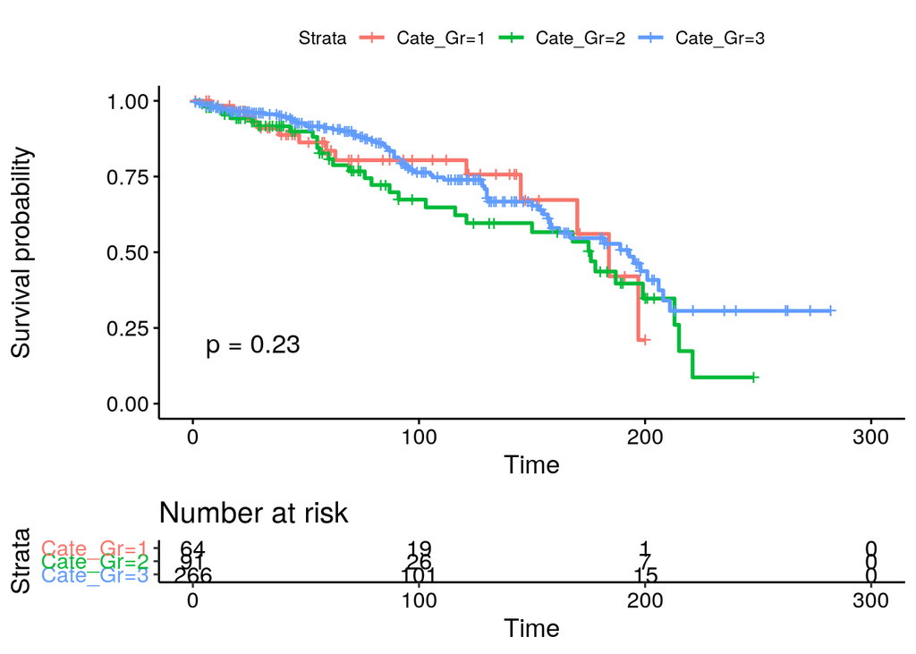

```
Call: survfit(formula = TS ~ Cate_Gr, data = LMS_surv)

                Cate_Gr=1
        time       n.risk      n.event     survival      std.err lower 95% CI upper 95% CI
     60.0000      28.0000       8.0000       0.8348       0.0547       0.7343       0.9492

                Cate_Gr=2
        time       n.risk      n.event     survival      std.err lower 95% CI upper 95% CI
     60.0000      43.0000      13.0000       0.8076       0.0496       0.7161       0.9108

                Cate_Gr=3
        time       n.risk      n.event     survival      std.err lower 95% CI upper 95% CI
     60.0000     163.0000      20.0000       0.9103       0.0194       0.8731       0.9490
```

```
Call: survfit(formula = TS ~ Cate_Gr, data = LMS_surv)

                Cate_Gr=1
        time       n.risk      n.event     survival      std.err lower 95% CI upper 95% CI
    120.0000      17.0000       9.0000       0.8039       0.0608       0.6932       0.9323

                Cate_Gr=2
        time       n.risk      n.event     survival      std.err lower 95% CI upper 95% CI
    120.0000      24.0000      21.0000       0.6221       0.0696       0.4997       0.7745

                Cate_Gr=3
        time       n.risk      n.event     survival      std.err lower 95% CI upper 95% CI
    120.0000      80.0000      45.0000       0.7393       0.0348       0.6741       0.8109
```

```
 mycph : perform coxph of individual expecting variables

 Call: TS ~ ., data= cox_trim

Cate_VisMPS  was excluded : infinite
PMH_prePVD  was excluded : infinite
PMH_LDS  was excluded : infinite
Comb_Tvsurgery  was excluded : infinite
Comb_Maze  was excluded : infinite
```

```
                     HR  lcl   ucl     p
Info_Male          0.68 0.47  0.99 0.041
Info_Age           1.05 1.04  1.07 0.000
Cate_CMPS          1.06 0.60  1.85 0.851
Cate_NeuMPS        1.43 0.45  4.55 0.544
Cate_CoroMPS       1.20 0.44  3.27 0.722
Cate_RenMPS        1.18 0.37  3.72 0.779
Cate_ExtMPS        0.90 0.39  2.04 0.795
Cate_SCMPS         1.43 0.98  2.11 0.066
Cate_NeuSCM        1.91 0.88  4.15 0.102
Cate_coroSCM       1.24 0.75  2.06 0.400
Cate_renSCM        1.24 0.66  2.31 0.504
Cate_ExtSCM        1.79 0.82  3.88 0.144
Cate_VisSCM        0.83 0.31  2.27 0.724
Cate_F-2           1.44 0.95  2.20 0.088
Cate_F-1           1.17 0.65  2.08 0.602
PMH_preHTN         1.62 1.10  2.39 0.014
PMH_preDM          1.43 0.66  3.07 0.364
PMH_preSmok        0.74 0.50  1.11 0.143
PMH_preCVAhx       1.87 0.91  3.86 0.090
PMH_preCLD         0.63 0.09  4.51 0.644
PMH_preCAD         1.22 0.38  3.88 0.734
PMH_preCKD         4.80 0.65 35.32 0.124
PMH_preAKI         0.78 0.11  5.57 0.801
PMH_Redo           0.69 0.10  4.99 0.717
PMH_RedoAo         1.03 0.14  7.38 0.979
PMH_Marfan         0.23 0.09  0.63 0.004
Lab_Hb             0.84 0.77  0.92 0.000
Lab_HCT            0.95 0.92  0.98 0.000
Lab_PLT            1.00 1.00  1.00 0.316
Lab_CRP            1.07 1.02  1.11 0.002
Lab_AST            1.00 1.00  1.00 0.385
Lab_ALT            1.00 1.00  1.00 0.862
Lab_Tb             0.92 0.60  1.43 0.720
Lab_BUN            1.01 0.99  1.02 0.440
Lab_Cr             1.08 0.91  1.29 0.378
Lab_eGFR           0.99 0.98  1.00 0.094
Lab_Amylise        1.00 1.00  1.01 0.318
Lab_Lipase         1.00 1.00  1.01 0.223
Lab_CKMB           1.01 1.00  1.01 0.047
Lab_TnI            1.01 0.99  1.03 0.228
Op_Root            0.62 0.38  1.03 0.063
Op_Bentall         0.98 0.59  1.62 0.924
Op_sparing         0.24 0.06  0.95 0.043
Op_Elephant        1.18 0.29  4.83 0.813
Op_Frozen          2.31 0.32 16.74 0.408
Op_factor2         1.02 0.67  1.54 0.935
Op_factor3         0.64 0.15  2.65 0.535
Op_factor4         0.66 0.35  1.23 0.190
Comb_Surgery       0.91 0.63  1.32 0.634
Comb_Avsurgery     0.96 0.65  1.43 0.846
Comb_CABG          1.17 0.69  1.98 0.567
Comb_Mvsurgery     0.45 0.06  3.24 0.428
Comb_PFO           0.74 0.18  3.01 0.676
Comb_PVDbypass     0.67 0.25  1.82 0.436
CPB_CPB            1.00 0.99  1.00 0.167
CPB_ACC            1.00 0.99  1.00 0.031
CPB_TCA            1.00 0.99  1.01 0.937
CPB_SCP            0.99 0.98  1.00 0.079
CPB_nasal_T        0.93 0.87  1.00 0.056
CPB_rect_bladder_T 0.94 0.88  1.01 0.119
```

```
             HR  lcl  ucl     p
Info_Male  0.68 0.47 0.99 0.041
Info_Age   1.05 1.04 1.07 0.000
PMH_preHTN 1.62 1.10 2.39 0.014
PMH_Marfan 0.23 0.09 0.63 0.004
Lab_Hb     0.84 0.77 0.92 0.000
Lab_HCT    0.95 0.92 0.98 0.000
Lab_CRP    1.07 1.02 1.11 0.002
Lab_CKMB   1.01 1.00 1.01 0.047
Op_sparing 0.24 0.06 0.95 0.043
CPB_ACC    1.00 0.99 1.00 0.031
```

```
Call:
coxph(formula = TS ~ ., data = .)

                         coef  exp(coef)   se(coef)      z       p
Info_Male          -3.362e-01  7.145e-01  1.047e+00 -0.321 0.74823
Info_Age            8.736e-02  1.091e+00  3.031e-02  2.882 0.00395
Cate_NeuSCM         1.653e+00  5.224e+00  9.900e-01  1.670 0.09491
Cate_ExtSCM        -4.902e-02  9.522e-01  8.889e-01 -0.055 0.95602
PMH_preHTN         -4.042e-01  6.675e-01  7.174e-01 -0.563 0.57318
PMH_preSmok         1.836e+00  6.270e+00  7.134e-01  2.573 0.01008
PMH_preCVAhx       -2.309e+00  9.941e-02  1.203e+00 -1.919 0.05500
PMH_preCKD          2.087e-01  1.232e+00  1.776e+00  0.117 0.90647
PMH_Marfan          3.287e+00  2.675e+01  1.570e+00  2.094 0.03629
Lab_Hb             -5.077e-01  6.019e-01  9.418e-01 -0.539 0.58982
Lab_HCT             5.100e-03  1.005e+00  3.219e-01  0.016 0.98736
Lab_CRP            -4.352e-03  9.957e-01  4.755e-02 -0.092 0.92707
Lab_eGFR           -1.116e-02  9.889e-01  8.823e-03 -1.265 0.20587
Lab_CKMB            5.657e-02  1.058e+00  1.818e-02  3.112 0.00186
Op_Root             4.966e-02  1.051e+00  1.160e+00  0.043 0.96586
Op_sparing         -1.863e+01  8.121e-09  6.116e+03 -0.003 0.99757
CPB_CPB             1.081e-02  1.011e+00  8.467e-03  1.277 0.20178
CPB_ACC            -1.623e-03  9.984e-01  1.330e-02 -0.122 0.90284
CPB_SCP            -1.072e-02  9.893e-01  1.619e-02 -0.663 0.50762
CPB_nasal_T        -2.086e-02  9.794e-01  1.528e-01 -0.137 0.89141
CPB_rect_bladder_T  1.888e-01  1.208e+00  1.775e-01  1.063 0.28763

Likelihood ratio test=40.91  on 21 df, p=0.005759
n= 123, number of events= 21
   (298 observations deleted due to missingness)
```

```
   Info_Age PMH_preSmok  PMH_Marfan    Lab_CKMB
0.003953081 0.010079120 0.036289252 0.001861382
```

## Period study

1995~2008 vs. 2008~2018 - CMPS의 생존률 비교

```
Call: survfit(formula = TS ~ period, data = anal_data %>% filter(Cate_Gr ==
    1))

              n events median 0.95LCL 0.95UCL
period=FALSE 51     15     NA    65.6      NA
period=TRUE  28     14    174    61.1      NA
```

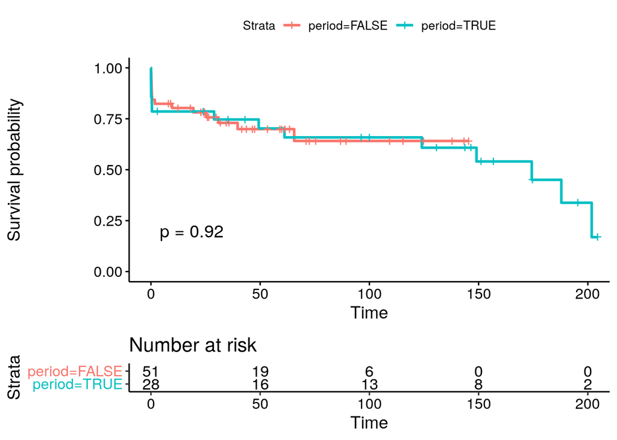

## Reoperation

```
Call: survfit(formula = reop_TS ~ Cate_Gr, data = anal_data)

            n events median 0.95LCL 0.95UCL
Cate_Gr=1  79      8     NA      NA      NA
Cate_Gr=2  99      8     NA      NA      NA
Cate_Gr=3 292     42     NA     215      NA
```

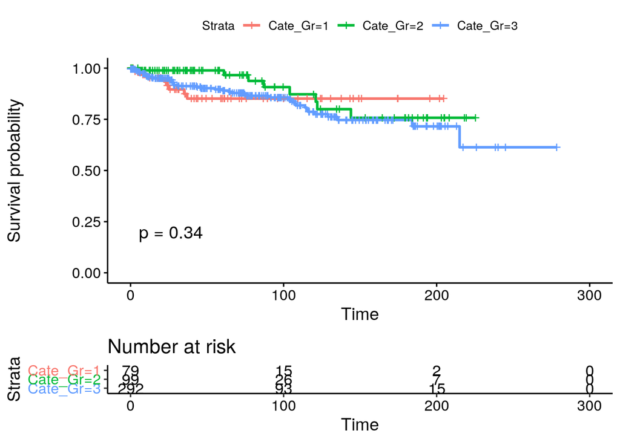

## 사망자 분석

|  | name | N | stats | class |
| --- | --- | --- | --- | --- |
| 1 | Outcome_COD | 29 |  | categorical |
| 2 | Bowel ischemia |  | 1 (3.4%) |  |
| 3 | Cardiogenic shock |  | 8 (27.6%) |  |
| 4 | CVA |  | 13 (44.8%) |  |
| 5 | MOF |  | 1 (3.4%) |  |
| 6 | Postoperative bleeding |  | 4 (13.8%) |  |
| 7 | Sepsis |  | 2 (6.9%) |  |

|  | 1 | 2 | 3 | p |  |
| --- | --- | --- | --- | --- | --- |
|  | (N=14) | (N=3) | (N=12) |  |  |
| Outcome_COD |  |  |  |  | 0.630 |
| Bowel ischemia | 1 ( 7.1%) | 0 ( 0.0%) | 0 ( 0.0%) |  |  |
| Cardiogenic shock | 4 (28.6%) | 0 ( 0.0%) | 4 (33.3%) |  |  |
| CVA | 4 (28.6%) | 2 (66.7%) | 7 (58.3%) |  |  |
| MOF | 1 ( 7.1%) | 0 ( 0.0%) | 0 ( 0.0%) |  |  |
| Postoperative bleeding | 2 (14.3%) | 1 (33.3%) | 1 ( 8.3%) |  |  |
| Sepsis | 2 (14.3%) | 0 ( 0.0%) | 0 ( 0.0%) |  |  |